# Chapter 11 - Norming the Senses

Bodo Winter

8/24/2018

## Introduction

This is the analysis script for Chapter 11, the first empirical chapter using data. This analysis mostly sets the ground for the other analyses in later chapters, providing a first look at the Lynott and Connell (2009) norms and some comparisons to other norm datasets.

We begin by loading in the data and libraries.

```r
## Libraries:

library(tidyverse)
library(stringr)

## Load data:

lyn <- read_csv('../raw-data/modality_lynott_connell_2009.csv')
sens <- read_csv('../raw-data/sensicon_tekiroglu_2014.csv')
strik <- read_csv('../raw-data/modality_strik_lievers_2015.csv')
dan <- read_csv('../raw-data/van_dantzig_2011_adjective_norms.csv')
noun <- read_csv('../raw-data/modality_lynott_connell_2013.csv')
SUBTLEX <- read_csv('../raw-data/frequency_SUBTLEX_POS.csv')
```

Some more preprocessing:

```r
## Vector of modality names:

mymods <- c('Visual', 'Haptic', 'Auditory',
            'Gustatory', 'Olfactory')

## Load plotting functions:

source('../functions/plot_density.R')
source('../functions/emptyplot.R')
```

Check the words “yellow” and “harsh” for reporting.

```r
## Yellow:

filter(lyn, Word == 'yellow') %>%
  select(VisualStrengthMean:ModalityExclusivity) %>%
  print(width = Inf)
```

```
## # A tibble: 1 x 6
##   VisualStrengthMean HapticStrengthMean AuditoryStrengthMean
##                <dbl>              <dbl>                <dbl>
## 1                4.9                  0                 0.15
##   GustatoryStrengthMean OlfactoryStrengthMean ModalityExclusivity
##                   <dbl>                 <dbl>               <dbl>
## 1                  0.05                  0.05               0.951
```

```r
## Harsh:

filter(lyn, Word == 'harsh') %>%
  select(VisualStrengthMean:ModalityExclusivity) %>%
  print(width = Inf)
```

```
## # A tibble: 1 x 6
##   VisualStrengthMean HapticStrengthMean AuditoryStrengthMean
##                <dbl>              <dbl>                <dbl>
## 1               3.19               2.52                 3.33
##   GustatoryStrengthMean OlfactoryStrengthMean ModalityExclusivity
##                   <dbl>                 <dbl>               <dbl>
## 1                  2.29                  1.81               0.116
```

Check the most and least exclusive:

```r
## Least exclusive:

arrange(lyn, ModalityExclusivity)
```

```
## # A tibble: 423 x 9
##    PropertyBritish Word      DominantModality VisualStrengthMean
##    <chr>           <chr>     <chr>                         <dbl>
##  1 strange         strange   Visual                         4.14
##  2 harsh           harsh     Auditory                       3.19
##  3 beautiful       beautiful Visual                         4.62
##  4 strong          strong    Visual                         3.90
##  5 brilliant       brilliant Visual                         3.95
##  6 brackish        brackish  Haptic                         2
##  7 burning         burning   Olfactory                      4.05
##  8 roasting        roasting  Visual                         4.05
##  9 grotesque       grotesque Visual                         4.38
## 10 crisp           crisp     Haptic                         3.10
## # ... with 413 more rows, and 5 more variables: HapticStrengthMean <dbl>,
## #   AuditoryStrengthMean <dbl>, GustatoryStrengthMean <dbl>,
## #   OlfactoryStrengthMean <dbl>, ModalityExclusivity <dbl>
```

```r
## Most exclusive:

arrange(lyn, desc(ModalityExclusivity))
```

```
## # A tibble: 423 x 9
##    PropertyBritish Word      DominantModality VisualStrengthMean
##    <chr>           <chr>     <chr>                         <dbl>
##  1 brunette        brunette  Visual                         4.8
##  2 yellow          yellow    Visual                         4.9
##  3 chequered       checkered Visual                         4.47
##  4 beige           beige     Visual                         4.48
##  5 blonde          blonde    Visual                         4.81
##  6 bright          bright    Visual                         5
##  7 purple          purple    Visual                         5
##  8 black           black     Visual                         4.57
##  9 white           white     Visual                         4.57
## 10 crimson         crimson   Visual                         4.43
## # ... with 413 more rows, and 5 more variables: HapticStrengthMean <dbl>,
## #   AuditoryStrengthMean <dbl>, GustatoryStrengthMean <dbl>,
## #   OlfactoryStrengthMean <dbl>, ModalityExclusivity <dbl>
```

## Plot of average exclusivity

This is figure 2 in the book, which shows the distribution of exclusivities across the whole set of adjectives.

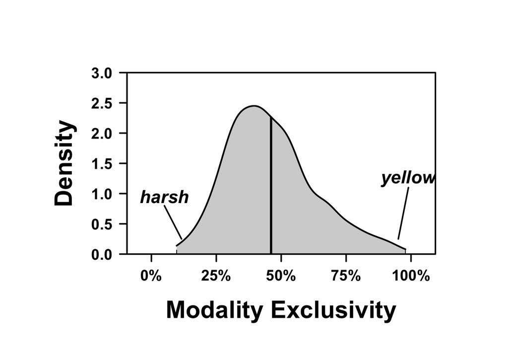

```r
text_height_factor <- 0.15
cex_text <- 1.5
quartz('', 9, 6)
par(mai = c(1.5, 1.75, 1, 1))
emptyplot(xlim = c(-0.05, 1.05), ylim = c(0, 3),
          yaxs = 'i', AB = '', yfactor = 0.07)
plot_density(lyn$ModalityExclusivity,
             mean = TRUE, this_color = 'lightgray')
axis(side = 1, at = seq(0, 1, 0.25),
     labels = str_c(seq(0, 100, 25), '%'), font = 2,
     lwd = 2, lwd.ticks = 2, cex.axis = 1.25)
mtext(side = 1, text = 'Modality Exclusivity',
      line = 3.6, cex = 2, font = 2)
axis(side = 2, at = seq(0, 3, 0.5), font = 2,
    lwd = 2, lwd.ticks = 2, cex.axis = 1.25, las = 2)
mtext(side = 2, text = 'Density',
      line = 3.6, cex = 2, font = 2)
## Add some labels:
segments(x0 = 0.116, x1 = 0.05, y0 = 0.25, y1 = 0.8, lwd = 2)
text(x = 0.05, y = 0.8 + text_height_factor,
     labels = 'harsh', font = 4, cex = cex_text)
segments(x0 = 0.951, x1 = 0.99, y0 = 0.25, y1 = 1.1, lwd = 2)
text(x = 0.99, y = 1.1 + text_height_factor,
     labels = 'yellow', font = 4, cex = cex_text)
```

## Adjectives versus nouns

Average exclusivities for both:

```r
mean(lyn$ModalityExclusivity)
```

```
## [1] 0.4610069
```

```r
mean(noun$ModalityExclusivity)
```

```
## [1] 0.3919191
```

Test of adjective versus noun exclusivity:

```r
wilcox.test(lyn$ModalityExclusivity,
            noun$ModalityExclusivity)
```

```
##
##  Wilcoxon rank sum test with continuity correction
##
## data:  lyn$ModalityExclusivity and noun$ModalityExclusivity
## W = 103270, p-value = 4.353e-08
## alternative hypothesis: true location shift is not equal to 0
```

## Highest perceptual strength ratings

Check the words with the highest perceptual strength ratings for each modality.

```r
arrange(lyn, desc(VisualStrengthMean)) %>% pull(Word) %>% head(1)
```

```
## [1] "bright"
```

```r
arrange(lyn, desc(HapticStrengthMean)) %>% pull(Word) %>% head(1)
```

```
## [1] "smooth"
```

```r
arrange(lyn, desc(AuditoryStrengthMean)) %>% pull(Word) %>% head(1)
```

```
## [1] "barking"
```

```r
arrange(lyn, desc(GustatoryStrengthMean)) %>% pull(Word) %>% head(1)
```

```
## [1] "citrusy"
```

```r
arrange(lyn, desc(OlfactoryStrengthMean)) %>% pull(Word) %>% head(1)
```

```
## [1] "fragrant"
```

## Problematic cases

Discuss problematic cases.

```r
## Check norms for "brackish" and "clamorous"

filter(lyn, Word == 'clamorous') %>% print(width = Inf)
```

```
## # A tibble: 1 x 9
##   PropertyBritish Word      DominantModality VisualStrengthMean
##   <chr>           <chr>     <chr>                         <dbl>
## 1 clamorous       clamorous Haptic                         2.25
##   HapticStrengthMean AuditoryStrengthMean GustatoryStrengthMean
##                <dbl>                <dbl>                 <dbl>
## 1               2.88                 2.38                 0.125
##   OlfactoryStrengthMean ModalityExclusivity
##                   <dbl>               <dbl>
## 1                 0.875               0.324
```

```r
filter(lyn, Word == 'brackish') %>% print(width = Inf)
```

```
## # A tibble: 1 x 9
##   PropertyBritish Word     DominantModality VisualStrengthMean
##   <chr>           <chr>    <chr>                         <dbl>
## 1 brackish        brackish Haptic                            2
##   HapticStrengthMean AuditoryStrengthMean GustatoryStrengthMean
##                <dbl>                <dbl>                 <dbl>
## 1                  3                  1.5                   1.5
##   OlfactoryStrengthMean ModalityExclusivity
##                   <dbl>               <dbl>
## 1                     2                0.15
```

## Table of most frequent / infrequent:

Let’s check the most and least frequent word per modality (reported in Table 5).

```r
## Merge:

lyn <- left_join(lyn, select(SUBTLEX, Word, FREQcount, Lg10WF))
noun <- left_join(noun, select(SUBTLEX, Word, FREQcount, Lg10WF))
## Most frequent:

lyn %>% arrange(desc(Lg10WF)) %>%
  filter(DominantModality == 'Visual') %>% head(2)
```

```
## # A tibble: 2 x 11
##   PropertyBritish Word  DominantModality VisualStrengthM… HapticStrengthM…
##   <chr>           <chr> <chr>                       <dbl>            <dbl>
## 1 little          litt… Visual                       4.67             3.24
## 2 big             big   Visual                       4.86             4.38
## # ... with 6 more variables: AuditoryStrengthMean <dbl>,
## #   GustatoryStrengthMean <dbl>, OlfactoryStrengthMean <dbl>,
## #   ModalityExclusivity <dbl>, FREQcount <int>, Lg10WF <dbl>
```

```r
lyn %>% arrange(desc(Lg10WF)) %>%
  filter(DominantModality == 'Haptic') %>% head(2)
```

```
## # A tibble: 2 x 11
##   PropertyBritish Word  DominantModality VisualStrengthM… HapticStrengthM…
##   <chr>           <chr> <chr>                       <dbl>            <dbl>
## 1 hard            hard  Haptic                       3.90             4.71
## 2 cool            cool  Haptic                       2.43             4.33
## # ... with 6 more variables: AuditoryStrengthMean <dbl>,
## #   GustatoryStrengthMean <dbl>, OlfactoryStrengthMean <dbl>,
## #   ModalityExclusivity <dbl>, FREQcount <int>, Lg10WF <dbl>
```

```r
lyn %>% arrange(desc(Lg10WF)) %>%
  filter(DominantModality == 'Auditory') %>% head(2)
```

```
## # A tibble: 2 x 11
##   PropertyBritish Word  DominantModality VisualStrengthM… HapticStrengthM…
##   <chr>           <chr> <chr>                       <dbl>            <dbl>
## 1 quiet           quiet Auditory                     2.10           0.0952
## 2 crying          cryi… Auditory                     4.43           1.24
## # ... with 6 more variables: AuditoryStrengthMean <dbl>,
## #   GustatoryStrengthMean <dbl>, OlfactoryStrengthMean <dbl>,
## #   ModalityExclusivity <dbl>, FREQcount <int>, Lg10WF <dbl>
```

```r
lyn %>% arrange(desc(Lg10WF)) %>%
  filter(DominantModality == 'Gustatory') %>% head(2)
```

```
## # A tibble: 2 x 11
##   PropertyBritish Word  DominantModality VisualStrengthM… HapticStrengthM…
##   <chr>           <chr> <chr>                       <dbl>            <dbl>
## 1 sweet           sweet Gustatory                    2.19            0.571
## 2 delicious       deli… Gustatory                    3.38            1.33
## # ... with 6 more variables: AuditoryStrengthMean <dbl>,
## #   GustatoryStrengthMean <dbl>, OlfactoryStrengthMean <dbl>,
## #   ModalityExclusivity <dbl>, FREQcount <int>, Lg10WF <dbl>
```

```r
lyn %>% arrange(desc(Lg10WF)) %>%
  filter(DominantModality == 'Olfactory') %>% head(2)
```

```
## # A tibble: 2 x 11
##   PropertyBritish Word  DominantModality VisualStrengthM… HapticStrengthM…
##   <chr>           <chr> <chr>                       <dbl>            <dbl>
## 1 fresh           fresh Olfactory                    3.95             2.43
## 2 burning         burn… Olfactory                    4.05             3.62
## # ... with 6 more variables: AuditoryStrengthMean <dbl>,
## #   GustatoryStrengthMean <dbl>, OlfactoryStrengthMean <dbl>,
## #   ModalityExclusivity <dbl>, FREQcount <int>, Lg10WF <dbl>
```

```r
## Least frequent:

lyn %>% arrange(Lg10WF) %>%
  filter(DominantModality == 'Visual') %>% head(2)
```

```
## # A tibble: 2 x 11
##   PropertyBritish Word  DominantModality VisualStrengthM… HapticStrengthM…
##   <chr>           <chr> <chr>                       <dbl>            <dbl>
## 1 vegetal         vege… Visual                       3.91             1.45
## 2 craggy          crag… Visual                       3.47             2.67
## # ... with 6 more variables: AuditoryStrengthMean <dbl>,
## #   GustatoryStrengthMean <dbl>, OlfactoryStrengthMean <dbl>,
## #   ModalityExclusivity <dbl>, FREQcount <int>, Lg10WF <dbl>
```

```r
lyn %>% arrange(Lg10WF) %>%
  filter(DominantModality == 'Haptic') %>% head(2)
```

```
## # A tibble: 2 x 11
##   PropertyBritish Word  DominantModality VisualStrengthM… HapticStrengthM…
##   <chr>           <chr> <chr>                       <dbl>            <dbl>
## 1 bristly         bris… Haptic                        4.3             4.65
## 2 brackish        brac… Haptic                        2               3
## # ... with 6 more variables: AuditoryStrengthMean <dbl>,
## #   GustatoryStrengthMean <dbl>, OlfactoryStrengthMean <dbl>,
## #   ModalityExclusivity <dbl>, FREQcount <int>, Lg10WF <dbl>
```

```r
lyn %>% arrange(Lg10WF) %>%
  filter(DominantModality == 'Auditory') %>% head(2)
```

```
## # A tibble: 2 x 11
##   PropertyBritish Word  DominantModality VisualStrengthM… HapticStrengthM…
##   <chr>           <chr> <chr>                       <dbl>            <dbl>
## 1 soundless       soun… Auditory                    1.71             0.333
## 2 sonorous        sono… Auditory                    0.667            0.889
## # ... with 6 more variables: AuditoryStrengthMean <dbl>,
## #   GustatoryStrengthMean <dbl>, OlfactoryStrengthMean <dbl>,
## #   ModalityExclusivity <dbl>, FREQcount <int>, Lg10WF <dbl>
```

```r
lyn %>% arrange(Lg10WF) %>%
  filter(DominantModality == 'Gustatory') %>% head(2)
```

```
## # A tibble: 2 x 11
##   PropertyBritish Word  DominantModality VisualStrengthM… HapticStrengthM…
##   <chr>           <chr> <chr>                       <dbl>            <dbl>
## 1 honeyed         hone… Gustatory                    3.05             1.33
## 2 orangey         oran… Gustatory                    4.24             1.57
## # ... with 6 more variables: AuditoryStrengthMean <dbl>,
## #   GustatoryStrengthMean <dbl>, OlfactoryStrengthMean <dbl>,
## #   ModalityExclusivity <dbl>, FREQcount <int>, Lg10WF <dbl>
```

```r
lyn %>% arrange(Lg10WF) %>%
  filter(DominantModality == 'Olfactory') %>% head(2)
```

```
## # A tibble: 2 x 11
##   PropertyBritish Word  DominantModality VisualStrengthM… HapticStrengthM…
##   <chr>           <chr> <chr>                       <dbl>            <dbl>
## 1 odorous         odor… Olfactory                    1.14            0.190
## 2 acrid           acrid Olfactory                    1.12            0.625
## # ... with 6 more variables: AuditoryStrengthMean <dbl>,
## #   GustatoryStrengthMean <dbl>, OlfactoryStrengthMean <dbl>,
## #   ModalityExclusivity <dbl>, FREQcount <int>, Lg10WF <dbl>
```

Repeat this for nouns:

```r
## Most frequent:

noun %>% arrange(desc(Lg10WF)) %>%
  filter(DominantModality == 'Visual') %>% head(2)
```

```
## # A tibble: 2 x 10
##   Word  DominantModality VisualStrengthMean AuditoryStrengthMean
##   <chr> <chr>                         <dbl>                <dbl>
## 1 want  Visual                         2.88                2
## 2 back  Visual                         3.94                0.647
## # ... with 6 more variables: HapticStrengthMean <dbl>,
## #   GustatoryStrengthMean <dbl>, OlfactoryStrengthMean <dbl>,
## #   ModalityExclusivity <dbl>, FREQcount <int>, Lg10WF <dbl>
```

```r
noun %>% arrange(desc(Lg10WF)) %>%
  filter(DominantModality == 'Haptic') %>% head(2)
```

```
## # A tibble: 2 x 10
##   Word  DominantModality VisualStrengthMean AuditoryStrengthMean
##   <chr> <chr>                         <dbl>                <dbl>
## 1 feel  Haptic                         1.94                1.24
## 2 hold  Haptic                         3.06                0.294
## # ... with 6 more variables: HapticStrengthMean <dbl>,
## #   GustatoryStrengthMean <dbl>, OlfactoryStrengthMean <dbl>,
## #   ModalityExclusivity <dbl>, FREQcount <int>, Lg10WF <dbl>
```

```r
noun %>% arrange(desc(Lg10WF)) %>%
  filter(DominantModality == 'Auditory') %>% head(2)
```

```
## # A tibble: 2 x 10
##   Word  DominantModality VisualStrengthMean AuditoryStrengthMean
##   <chr> <chr>                         <dbl>                <dbl>
## 1 help  Auditory                       3.65                 3.76
## 2 god   Auditory                       1.18                 1.82
## # ... with 6 more variables: HapticStrengthMean <dbl>,
## #   GustatoryStrengthMean <dbl>, OlfactoryStrengthMean <dbl>,
## #   ModalityExclusivity <dbl>, FREQcount <int>, Lg10WF <dbl>
```

```r
noun %>% arrange(desc(Lg10WF)) %>%
  filter(DominantModality == 'Gustatory') %>% head(2)
```

```
## # A tibble: 2 x 10
##   Word  DominantModality VisualStrengthMean AuditoryStrengthMean
##   <chr> <chr>                         <dbl>                <dbl>
## 1 honey Gustatory                      4.12                0.647
## 2 food  Gustatory                      4.29                1.47
## # ... with 6 more variables: HapticStrengthMean <dbl>,
## #   GustatoryStrengthMean <dbl>, OlfactoryStrengthMean <dbl>,
## #   ModalityExclusivity <dbl>, FREQcount <int>, Lg10WF <dbl>
```

```r
noun %>% arrange(desc(Lg10WF)) %>%
  filter(DominantModality == 'Olfactory') %>% head(2)
```

```
## # A tibble: 2 x 10
##   Word   DominantModality VisualStrengthMean AuditoryStrengthMean
##   <chr>  <chr>                         <dbl>                <dbl>
## 1 air    Olfactory                      1.35                 1.06
## 2 breath Olfactory                      1.71                 2.18
## # ... with 6 more variables: HapticStrengthMean <dbl>,
## #   GustatoryStrengthMean <dbl>, OlfactoryStrengthMean <dbl>,
## #   ModalityExclusivity <dbl>, FREQcount <int>, Lg10WF <dbl>
```

```r
## Least frequent:

noun %>% arrange(Lg10WF) %>%
  filter(DominantModality == 'Visual') %>% head(2)
```

```
## # A tibble: 2 x 10
##   Word      DominantModality VisualStrengthMean AuditoryStrengthMean
##   <chr>     <chr>                         <dbl>                <dbl>
## 1 provision Visual                         2.35                0.938
## 2 builder   Visual                         4.29                3.76
## # ... with 6 more variables: HapticStrengthMean <dbl>,
## #   GustatoryStrengthMean <dbl>, OlfactoryStrengthMean <dbl>,
## #   ModalityExclusivity <dbl>, FREQcount <int>, Lg10WF <dbl>
```

```r
noun %>% arrange(Lg10WF) %>%
  filter(DominantModality == 'Haptic') %>% head(2)
```

```
## # A tibble: 2 x 10
##   Word   DominantModality VisualStrengthMean AuditoryStrengthMean
##   <chr>  <chr>                         <dbl>                <dbl>
## 1 strain Haptic                         3                    2.12
## 2 item   Haptic                         4.06                 2.75
## # ... with 6 more variables: HapticStrengthMean <dbl>,
## #   GustatoryStrengthMean <dbl>, OlfactoryStrengthMean <dbl>,
## #   ModalityExclusivity <dbl>, FREQcount <int>, Lg10WF <dbl>
```

```r
noun %>% arrange(Lg10WF) %>%
  filter(DominantModality == 'Auditory') %>% head(2)
```

```
## # A tibble: 2 x 10
##   Word      DominantModality VisualStrengthMean AuditoryStrengthMean
##   <chr>     <chr>                         <dbl>                <dbl>
## 1 socialist Auditory                       2.5                  2.56
## 2 quarrel   Auditory                       3.94                 4.65
## # ... with 6 more variables: HapticStrengthMean <dbl>,
## #   GustatoryStrengthMean <dbl>, OlfactoryStrengthMean <dbl>,
## #   ModalityExclusivity <dbl>, FREQcount <int>, Lg10WF <dbl>
```

```r
noun %>% arrange(Lg10WF) %>%
  filter(DominantModality == 'Gustatory') %>% head(2)
```

```
## # A tibble: 2 x 10
##   Word   DominantModality VisualStrengthMean AuditoryStrengthMean
##   <chr>  <chr>                         <dbl>                <dbl>
## 1 sauce  Gustatory                      3.59                 1.06
## 2 supper Gustatory                      4.35                 1.71
## # ... with 6 more variables: HapticStrengthMean <dbl>,
## #   GustatoryStrengthMean <dbl>, OlfactoryStrengthMean <dbl>,
## #   ModalityExclusivity <dbl>, FREQcount <int>, Lg10WF <dbl>
```

```r
noun %>% arrange(Lg10WF) %>%
  filter(DominantModality == 'Olfactory') %>% head(2)
```

```
## # A tibble: 2 x 10
##   Word   DominantModality VisualStrengthMean AuditoryStrengthMean
##   <chr>  <chr>                         <dbl>                <dbl>
## 1 breath Olfactory                      1.71                 2.18
## 2 air    Olfactory                      1.35                 1.06
## # ... with 6 more variables: HapticStrengthMean <dbl>,
## #   GustatoryStrengthMean <dbl>, OlfactoryStrengthMean <dbl>,
## #   ModalityExclusivity <dbl>, FREQcount <int>, Lg10WF <dbl>
```

## Table of most / least exclusive:

And the most/least exclusive.

```r
## Most exclusive:

lyn %>% arrange(desc(ModalityExclusivity)) %>%
  filter(DominantModality == 'Visual') %>% head(2)
```

```
## # A tibble: 2 x 11
##   PropertyBritish Word  DominantModality VisualStrengthM… HapticStrengthM…
##   <chr>           <chr> <chr>                       <dbl>            <dbl>
## 1 brunette        brun… Visual                        4.8                0
## 2 yellow          yell… Visual                        4.9                0
## # ... with 6 more variables: AuditoryStrengthMean <dbl>,
## #   GustatoryStrengthMean <dbl>, OlfactoryStrengthMean <dbl>,
## #   ModalityExclusivity <dbl>, FREQcount <int>, Lg10WF <dbl>
```

```r
lyn %>% arrange(desc(ModalityExclusivity)) %>%
  filter(DominantModality == 'Haptic') %>% head(2)
```

```
## # A tibble: 2 x 11
##   PropertyBritish Word  DominantModality VisualStrengthM… HapticStrengthM…
##   <chr>           <chr> <chr>                       <dbl>            <dbl>
## 1 stinging        stin… Haptic                       1.76             4.67
## 2 tingly          ting… Haptic                       0.9              4.8
## # ... with 6 more variables: AuditoryStrengthMean <dbl>,
## #   GustatoryStrengthMean <dbl>, OlfactoryStrengthMean <dbl>,
## #   ModalityExclusivity <dbl>, FREQcount <int>, Lg10WF <dbl>
```

```r
lyn %>% arrange(desc(ModalityExclusivity)) %>%
  filter(DominantModality == 'Auditory') %>% head(2)
```

```
## # A tibble: 2 x 11
##   PropertyBritish Word  DominantModality VisualStrengthM… HapticStrengthM…
##   <chr>           <chr> <chr>                       <dbl>            <dbl>
## 1 echoing         echo… Auditory                    0.524            0.333
## 2 deafening       deaf… Auditory                    1.24             0.190
## # ... with 6 more variables: AuditoryStrengthMean <dbl>,
## #   GustatoryStrengthMean <dbl>, OlfactoryStrengthMean <dbl>,
## #   ModalityExclusivity <dbl>, FREQcount <int>, Lg10WF <dbl>
```

```r
lyn %>% arrange(desc(ModalityExclusivity)) %>%
  filter(DominantModality == 'Gustatory') %>% head(2)
```

```
## # A tibble: 2 x 11
##   PropertyBritish Word  DominantModality VisualStrengthM… HapticStrengthM…
##   <chr>           <chr> <chr>                       <dbl>            <dbl>
## 1 bitter          bitt… Gustatory                   0.857           0.0952
## 2 sour            sour  Gustatory                   1.19            0.0476
## # ... with 6 more variables: AuditoryStrengthMean <dbl>,
## #   GustatoryStrengthMean <dbl>, OlfactoryStrengthMean <dbl>,
## #   ModalityExclusivity <dbl>, FREQcount <int>, Lg10WF <dbl>
```

```r
lyn %>% arrange(desc(ModalityExclusivity)) %>%
  filter(DominantModality == 'Olfactory') %>% head(2)
```

```
## # A tibble: 2 x 11
##   PropertyBritish Word  DominantModality VisualStrengthM… HapticStrengthM…
##   <chr>           <chr> <chr>                       <dbl>            <dbl>
## 1 perfumed        perf… Olfactory                   0.476            0.190
## 2 whiffy          whif… Olfactory                   0.95             0.2
## # ... with 6 more variables: AuditoryStrengthMean <dbl>,
## #   GustatoryStrengthMean <dbl>, OlfactoryStrengthMean <dbl>,
## #   ModalityExclusivity <dbl>, FREQcount <int>, Lg10WF <dbl>
```

```r
## Least exclusive:

lyn %>% arrange(ModalityExclusivity) %>%
  filter(DominantModality == 'Visual') %>% head(2)
```

```
## # A tibble: 2 x 11
##   PropertyBritish Word  DominantModality VisualStrengthM… HapticStrengthM…
##   <chr>           <chr> <chr>                       <dbl>            <dbl>
## 1 strange         stra… Visual                       4.14             2.52
## 2 beautiful       beau… Visual                       4.62             2.76
## # ... with 6 more variables: AuditoryStrengthMean <dbl>,
## #   GustatoryStrengthMean <dbl>, OlfactoryStrengthMean <dbl>,
## #   ModalityExclusivity <dbl>, FREQcount <int>, Lg10WF <dbl>
```

```r
lyn %>% arrange(ModalityExclusivity) %>%
  filter(DominantModality == 'Haptic') %>% head(2)
```

```
## # A tibble: 2 x 11
##   PropertyBritish Word  DominantModality VisualStrengthM… HapticStrengthM…
##   <chr>           <chr> <chr>                       <dbl>            <dbl>
## 1 brackish        brac… Haptic                       2                3
## 2 crisp           crisp Haptic                       3.10             3.38
## # ... with 6 more variables: AuditoryStrengthMean <dbl>,
## #   GustatoryStrengthMean <dbl>, OlfactoryStrengthMean <dbl>,
## #   ModalityExclusivity <dbl>, FREQcount <int>, Lg10WF <dbl>
```

```r
lyn %>% arrange(ModalityExclusivity) %>%
  filter(DominantModality == 'Auditory') %>% head(2)
```

```
## # A tibble: 2 x 11
##   PropertyBritish Word  DominantModality VisualStrengthM… HapticStrengthM…
##   <chr>           <chr> <chr>                       <dbl>            <dbl>
## 1 harsh           harsh Auditory                     3.19             2.52
## 2 crunching       crun… Auditory                     2.14             2.14
## # ... with 6 more variables: AuditoryStrengthMean <dbl>,
## #   GustatoryStrengthMean <dbl>, OlfactoryStrengthMean <dbl>,
## #   ModalityExclusivity <dbl>, FREQcount <int>, Lg10WF <dbl>
```

```r
lyn %>% arrange(ModalityExclusivity) %>%
  filter(DominantModality == 'Gustatory') %>% head(2)
```

```
## # A tibble: 2 x 11
##   PropertyBritish Word  DominantModality VisualStrengthM… HapticStrengthM…
##   <chr>           <chr> <chr>                       <dbl>            <dbl>
## 1 mild            mild  Gustatory                    2.19             1.38
## 2 roasted         roas… Gustatory                    4.19             1.76
## # ... with 6 more variables: AuditoryStrengthMean <dbl>,
## #   GustatoryStrengthMean <dbl>, OlfactoryStrengthMean <dbl>,
## #   ModalityExclusivity <dbl>, FREQcount <int>, Lg10WF <dbl>
```

```r
lyn %>% arrange(ModalityExclusivity) %>%
  filter(DominantModality == 'Olfactory') %>% head(2)
```

```
## # A tibble: 2 x 11
##   PropertyBritish Word  DominantModality VisualStrengthM… HapticStrengthM…
##   <chr>           <chr> <chr>                       <dbl>            <dbl>
## 1 burning         burn… Olfactory                    4.05             3.62
## 2 fresh           fresh Olfactory                    3.95             2.43
## # ... with 6 more variables: AuditoryStrengthMean <dbl>,
## #   GustatoryStrengthMean <dbl>, OlfactoryStrengthMean <dbl>,
## #   ModalityExclusivity <dbl>, FREQcount <int>, Lg10WF <dbl>
```

Same for nouns:

```r
## Most exclusive:

noun %>% arrange(desc(ModalityExclusivity)) %>%
  filter(DominantModality == 'Visual') %>% head(2)
```

```
## # A tibble: 2 x 10
##   Word       DominantModality VisualStrengthMean AuditoryStrengthMean
##   <chr>      <chr>                         <dbl>                <dbl>
## 1 reflection Visual                         4.65                0.235
## 2 sight      Visual                         5                   0.471
## # ... with 6 more variables: HapticStrengthMean <dbl>,
## #   GustatoryStrengthMean <dbl>, OlfactoryStrengthMean <dbl>,
## #   ModalityExclusivity <dbl>, FREQcount <int>, Lg10WF <dbl>
```

```r
noun %>% arrange(desc(ModalityExclusivity)) %>%
  filter(DominantModality == 'Haptic') %>% head(2)
```

```
## # A tibble: 2 x 10
##   Word  DominantModality VisualStrengthMean AuditoryStrengthMean
##   <chr> <chr>                         <dbl>                <dbl>
## 1 hold  Haptic                         3.06                0.294
## 2 felt  Haptic                         2.82                0.706
## # ... with 6 more variables: HapticStrengthMean <dbl>,
## #   GustatoryStrengthMean <dbl>, OlfactoryStrengthMean <dbl>,
## #   ModalityExclusivity <dbl>, FREQcount <int>, Lg10WF <dbl>
```

```r
noun %>% arrange(desc(ModalityExclusivity)) %>%
  filter(DominantModality == 'Auditory') %>% head(2)
```

```
## # A tibble: 2 x 10
##   Word  DominantModality VisualStrengthMean AuditoryStrengthMean
##   <chr> <chr>                         <dbl>                <dbl>
## 1 sound Auditory                      0.765                 5
## 2 myth  Auditory                      1.24                  4.06
## # ... with 6 more variables: HapticStrengthMean <dbl>,
## #   GustatoryStrengthMean <dbl>, OlfactoryStrengthMean <dbl>,
## #   ModalityExclusivity <dbl>, FREQcount <int>, Lg10WF <dbl>
```

```r
noun %>% arrange(desc(ModalityExclusivity)) %>%
  filter(DominantModality == 'Gustatory') %>% head(2)
```

```
## # A tibble: 2 x 10
##   Word  DominantModality VisualStrengthMean AuditoryStrengthMean
##   <chr> <chr>                         <dbl>                <dbl>
## 1 taste Gustatory                      1.25                0.235
## 2 honey Gustatory                      4.12                0.647
## # ... with 6 more variables: HapticStrengthMean <dbl>,
## #   GustatoryStrengthMean <dbl>, OlfactoryStrengthMean <dbl>,
## #   ModalityExclusivity <dbl>, FREQcount <int>, Lg10WF <dbl>
```

```r
noun %>% arrange(desc(ModalityExclusivity)) %>%
  filter(DominantModality == 'Olfactory') %>% head(2)
```

```
## # A tibble: 2 x 10
##   Word   DominantModality VisualStrengthMean AuditoryStrengthMean
##   <chr>  <chr>                         <dbl>                <dbl>
## 1 air    Olfactory                      1.35                 1.06
## 2 breath Olfactory                      1.71                 2.18
## # ... with 6 more variables: HapticStrengthMean <dbl>,
## #   GustatoryStrengthMean <dbl>, OlfactoryStrengthMean <dbl>,
## #   ModalityExclusivity <dbl>, FREQcount <int>, Lg10WF <dbl>
```

```r
## Least exclusive:

noun %>% arrange(ModalityExclusivity) %>%
  filter(DominantModality == 'Visual') %>% head(2)
```

```
## # A tibble: 2 x 10
##   Word    DominantModality VisualStrengthMean AuditoryStrengthMean
##   <chr>   <chr>                         <dbl>                <dbl>
## 1 quality Visual                         4.29                 3.06
## 2 variety Visual                         4.41                 3.29
## # ... with 6 more variables: HapticStrengthMean <dbl>,
## #   GustatoryStrengthMean <dbl>, OlfactoryStrengthMean <dbl>,
## #   ModalityExclusivity <dbl>, FREQcount <int>, Lg10WF <dbl>
```

```r
noun %>% arrange(ModalityExclusivity) %>%
  filter(DominantModality == 'Haptic') %>% head(2)
```

```
## # A tibble: 2 x 10
##   Word    DominantModality VisualStrengthMean AuditoryStrengthMean
##   <chr>   <chr>                         <dbl>                <dbl>
## 1 item    Haptic                         4.06                 2.75
## 2 contact Haptic                         3.41                 2.53
## # ... with 6 more variables: HapticStrengthMean <dbl>,
## #   GustatoryStrengthMean <dbl>, OlfactoryStrengthMean <dbl>,
## #   ModalityExclusivity <dbl>, FREQcount <int>, Lg10WF <dbl>
```

```r
noun %>% arrange(ModalityExclusivity) %>%
  filter(DominantModality == 'Auditory') %>% head(2)
```

```
## # A tibble: 2 x 10
##   Word   DominantModality VisualStrengthMean AuditoryStrengthMean
##   <chr>  <chr>                         <dbl>                <dbl>
## 1 heaven Auditory                       1.53                 1.76
## 2 past   Auditory                       2.18                 2.29
## # ... with 6 more variables: HapticStrengthMean <dbl>,
## #   GustatoryStrengthMean <dbl>, OlfactoryStrengthMean <dbl>,
## #   ModalityExclusivity <dbl>, FREQcount <int>, Lg10WF <dbl>
```

```r
noun %>% arrange(ModalityExclusivity) %>%
  filter(DominantModality == 'Gustatory') %>% head(2)
```

```
## # A tibble: 2 x 10
##   Word   DominantModality VisualStrengthMean AuditoryStrengthMean
##   <chr>  <chr>                         <dbl>                <dbl>
## 1 treat  Gustatory                      3.12                 1.59
## 2 supper Gustatory                      4.35                 1.71
## # ... with 6 more variables: HapticStrengthMean <dbl>,
## #   GustatoryStrengthMean <dbl>, OlfactoryStrengthMean <dbl>,
## #   ModalityExclusivity <dbl>, FREQcount <int>, Lg10WF <dbl>
```

```r
noun %>% arrange(ModalityExclusivity) %>%
  filter(DominantModality == 'Olfactory') %>% head(2)
```

```
## # A tibble: 2 x 10
##   Word   DominantModality VisualStrengthMean AuditoryStrengthMean
##   <chr>  <chr>                         <dbl>                <dbl>
## 1 breath Olfactory                      1.71                 2.18
## 2 air    Olfactory                      1.35                 1.06
## # ... with 6 more variables: HapticStrengthMean <dbl>,
## #   GustatoryStrengthMean <dbl>, OlfactoryStrengthMean <dbl>,
## #   ModalityExclusivity <dbl>, FREQcount <int>, Lg10WF <dbl>
```

## Comparison to van Dantzig et al. (2011)

In this section, we look at how much the Lynott & Connell (2009) norms correspond to the van Dantzig et al. (2011) norms.

```r
## Merge

lyndan <- left_join(lyn, dan, by = c('Word' = 'Word'))

## Perform pairwise correlations per modality:

cor.test(lyndan$VisualStrengthMean.x,
         lyndan$VisualStrengthMean.y, use = 'complete.obs')
```

```
##
##  Pearson's product-moment correlation
##
## data:  lyndan$VisualStrengthMean.x and lyndan$VisualStrengthMean.y
## t = 26.322, df = 363, p-value < 2.2e-16
## alternative hypothesis: true correlation is not equal to 0
## 95 percent confidence interval:
##  0.7715648 0.8426402
## sample estimates:
##       cor
## 0.8100576
```

```r
cor.test(lyndan$HapticStrengthMean.x,
         lyndan$HapticStrengthMean.y, use = 'complete.obs')
```

```
##
##  Pearson's product-moment correlation
##
## data:  lyndan$HapticStrengthMean.x and lyndan$HapticStrengthMean.y
## t = 33.331, df = 363, p-value < 2.2e-16
## alternative hypothesis: true correlation is not equal to 0
## 95 percent confidence interval:
##  0.8404176 0.8913835
## sample estimates:
##       cor
## 0.8681715
```

```r
cor.test(lyndan$AuditoryStrengthMean.x,
         lyndan$AuditoryStrengthMean.y, use = 'complete.obs')
```

```
##
##  Pearson's product-moment correlation
##
## data:  lyndan$AuditoryStrengthMean.x and lyndan$AuditoryStrengthMean.y
## t = 45.177, df = 363, p-value < 2.2e-16
## alternative hypothesis: true correlation is not equal to 0
## 95 percent confidence interval:
##  0.9042936 0.9355736
## sample estimates:
##       cor
## 0.9214129
```

```r
cor.test(lyndan$GustatoryStrengthMean.x,
         lyndan$GustatoryStrengthMean.y, use = 'complete.obs')
```

```
##
##  Pearson's product-moment correlation
##
## data:  lyndan$GustatoryStrengthMean.x and lyndan$GustatoryStrengthMean.y
## t = 32.177, df = 363, p-value < 2.2e-16
## alternative hypothesis: true correlation is not equal to 0
## 95 percent confidence interval:
##  0.8312440 0.8849566
## sample estimates:
##       cor
## 0.8604725
```

```r
cor.test(lyndan$OlfactoryStrengthMean.x,
         lyndan$OlfactoryStrengthMean.y, use = 'complete.obs')
```

```
##
##  Pearson's product-moment correlation
##
## data:  lyndan$OlfactoryStrengthMean.x and lyndan$OlfactoryStrengthMean.y
## t = 40.424, df = 363, p-value < 2.2e-16
## alternative hypothesis: true correlation is not equal to 0
## 95 percent confidence interval:
##  0.8839955 0.9216365
## sample estimates:
##       cor
## 0.9045635
```

```r
cor.test(lyndan$ModalityExclusivity.x,
         lyndan$ModalityExclusivity.y, use = 'complete.obs')
```

```
##
##  Pearson's product-moment correlation
##
## data:  lyndan$ModalityExclusivity.x and lyndan$ModalityExclusivity.y
## t = 21.688, df = 363, p-value < 2.2e-16
## alternative hypothesis: true correlation is not equal to 0
## 95 percent confidence interval:
##  0.7028364 0.7927948
## sample estimates:
##       cor
## 0.7512844
```

Correlations are really high, and that’s even though van Dantzig et al. (2011) provided noun contexts.

Let’s do the same for Spearman’s correlations (just to check, also because we can’t assume that the distributional assumptions are met).

```r
cor.test(lyndan$VisualStrengthMean.x,
         lyndan$VisualStrengthMean.y, use = 'complete.obs',
         method = 'spearman')
```

```
##
##  Spearman's rank correlation rho
##
## data:  lyndan$VisualStrengthMean.x and lyndan$VisualStrengthMean.y
## S = 1374200, p-value < 2.2e-16
## alternative hypothesis: true rho is not equal to 0
## sample estimates:
##       rho
## 0.8304377
```

```r
cor.test(lyndan$HapticStrengthMean.x,
         lyndan$HapticStrengthMean.y, use = 'complete.obs',
         method = 'spearman')
```

```
##
##  Spearman's rank correlation rho
##
## data:  lyndan$HapticStrengthMean.x and lyndan$HapticStrengthMean.y
## S = 1070500, p-value < 2.2e-16
## alternative hypothesis: true rho is not equal to 0
## sample estimates:
##       rho
## 0.8679091
```

```r
cor.test(lyndan$AuditoryStrengthMean.x,
         lyndan$AuditoryStrengthMean.y, use = 'complete.obs',
         method = 'spearman')
```

```
##
##  Spearman's rank correlation rho
##
## data:  lyndan$AuditoryStrengthMean.x and lyndan$AuditoryStrengthMean.y
## S = 1787900, p-value < 2.2e-16
## alternative hypothesis: true rho is not equal to 0
## sample estimates:
##       rho
## 0.7793949
```

```r
cor.test(lyndan$GustatoryStrengthMean.x,
         lyndan$GustatoryStrengthMean.y, use = 'complete.obs',
         method = 'spearman')
```

```
##
##  Spearman's rank correlation rho
##
## data:  lyndan$GustatoryStrengthMean.x and lyndan$GustatoryStrengthMean.y
## S = 1954200, p-value < 2.2e-16
## alternative hypothesis: true rho is not equal to 0
## sample estimates:
##       rho
## 0.7588765
```

```r
cor.test(lyndan$OlfactoryStrengthMean.x,
         lyndan$OlfactoryStrengthMean.y, use = 'complete.obs',
         method = 'spearman')
```

```
##
##  Spearman's rank correlation rho
##
## data:  lyndan$OlfactoryStrengthMean.x and lyndan$OlfactoryStrengthMean.y
## S = 1824000, p-value < 2.2e-16
## alternative hypothesis: true rho is not equal to 0
## sample estimates:
##      rho
## 0.774941
```

```r
cor.test(lyndan$ModalityExclusivity.x,
         lyndan$ModalityExclusivity.y, use = 'complete.obs',
         method = 'spearman')
```

```
##
##  Spearman's rank correlation rho
##
## data:  lyndan$ModalityExclusivity.x and lyndan$ModalityExclusivity.y
## S = 2203300, p-value < 2.2e-16
## alternative hypothesis: true rho is not equal to 0
## sample estimates:
##      rho
## 0.728142
```

An even better and more holistic way to look at the correspondence between the two datasets is to check the cosine between the two modality vectors, i.e., how much do the five modality values of Lynott and Connell (2009) correspond to the five modality values of van Dantzig et al. (2011)?

```r
## Load cosine similarity function:

source('../functions/cosine_sim.R')

## Loop word-wise and calculate cosines:

lyndan$Cosine <- NA
mymods_names <- str_c(mymods, 'StrengthMean')
for (i in 1:nrow(lyndan)) {
    lyn_vector <- unlist(lyndan[i, str_c(mymods_names, '.x')])
    dan_vector <- unlist(lyndan[i, str_c(mymods_names, '.y')])
    lyndan[i, ]$Cosine <- cosine_sim(lyn_vector, dan_vector)
    }

## What is the average cosine?

mean(lyndan$Cosine, na.rm = TRUE)   # 0.97
```

```
## [1] 0.9683313
```

```r
## What is the range?

range(lyndan$Cosine, na.rm = TRUE)
```

```
## [1] 0.7436401 0.9999035
```

Informally, let’s check what are dominant modality classifications that differ between the two languages?

```r
filter(lyndan,
       DominantModality.x != DominantModality.y) %>%
    select(Word,
           DominantModality.x, DominantModality.y)
```

```
## # A tibble: 67 x 3
##    Word       DominantModality.x DominantModality.y
##    <chr>      <chr>              <chr>
##  1 abrasive   Haptic             Visual
##  2 absorbent  Visual             Haptic
##  3 alcoholic  Gustatory          Olfactory
##  4 astringent Gustatory          Olfactory
##  5 barbecued  Gustatory          Olfactory
##  6 beautiful  Visual             Auditory
##  7 beery      Gustatory          Olfactory
##  8 bland      Gustatory          Visual
##  9 bouncy     Haptic             Visual
## 10 breezy     Visual             Haptic
## # ... with 57 more rows
```

```r
## Confusion matrix:

with(lyndan,
     print(lyndan_tab <<- table(DominantModality.x,
                                DominantModality.y)))
```

```
##                   DominantModality.y
## DominantModality.x Auditory Gustatory Haptic Olfactory Visual
##          Auditory        55         0      0         0      1
##          Gustatory        0        18      3        17      8
##          Haptic           2         1     48         0     16
##          Olfactory        0         0      1        15      2
##          Visual           5         2      6         3    162
```

```r
## Overlap:

sum(lyndan_tab)
```

```
## [1] 365
```

```r
sum(diag(lyndan_tab)) / sum(lyndan_tab)
```

```
## [1] 0.8164384
```

## Comparison to Strik Lievers (2015)

Strik Lievers (2015) used a thesaurus and dictionaries to derive a list of sensory words.

```r
lynstrik <- left_join(lyn, strik)
## Confusion matrix:

with(lynstrik,
     print(lynstrik_tab <<- table(DominantModality, Modality)))
```

```
##                 Modality
## DominantModality Auditory Gustatory Haptic Olfactory Visual
##        Auditory        10         0      0         0      0
##        Gustatory        0        10      0         0      0
##        Haptic           0         0     17         0      0
##        Olfactory        0         3      2         5      0
##        Visual           0         1      2         0     46
```

```r
## How much overlap?

sum(lynstrik_tab) # 96 overlapping
```

```
## [1] 96
```

```r
sum(diag(lynstrik_tab)) / sum(lynstrik_tab)
```

```
## [1] 0.9166667
```

## Comparison to Tekiroglu et al. (2014) Sensicon

Next, we compare the Lynott and Connell (2009) norms against the Sensicon.

```r
## Merge datasets:

lynsens <- left_join(lyn, sens, by = c('Word' = 'Word'))

## Perform correlations:

with(lynsens,
    cor.test(VisualStrength,
             VisualStrengthMean, use = 'complete.obs'))
```

```
##
##  Pearson's product-moment correlation
##
## data:  VisualStrength and VisualStrengthMean
## t = 7.0968, df = 410, p-value = 5.653e-12
## alternative hypothesis: true correlation is not equal to 0
## 95 percent confidence interval:
##  0.2418777 0.4141379
## sample estimates:
##       cor
## 0.3307601
```

```r
with(lynsens,
    cor.test(TactileStrength,
             HapticStrengthMean, use = 'complete.obs'))
```

```
##
##  Pearson's product-moment correlation
##
## data:  TactileStrength and HapticStrengthMean
## t = 5.6208, df = 410, p-value = 3.517e-08
## alternative hypothesis: true correlation is not equal to 0
## 95 percent confidence interval:
##  0.1754004 0.3549194
## sample estimates:
##       cor
## 0.2674794
```

```r
with(lynsens,
    cor.test(AuditoryStrength,
             AuditoryStrengthMean, use = 'complete.obs'))
```

```
##
##  Pearson's product-moment correlation
##
## data:  AuditoryStrength and AuditoryStrengthMean
## t = 6.7812, df = 410, p-value = 4.172e-11
## alternative hypothesis: true correlation is not equal to 0
## 95 percent confidence interval:
##  0.2279461 0.4018472
## sample estimates:
##       cor
## 0.3175643
```

```r
with(lynsens,
    cor.test(GustatoryStrength,
             GustatoryStrengthMean, use = 'complete.obs'))
```

```
##
##  Pearson's product-moment correlation
##
## data:  GustatoryStrength and GustatoryStrengthMean
## t = 11.853, df = 410, p-value < 2.2e-16
## alternative hypothesis: true correlation is not equal to 0
## 95 percent confidence interval:
##  0.4295506 0.5738024
## sample estimates:
##       cor
## 0.5051968
```

```r
with(lynsens,
    cor.test(OlfactoryStrength,
             OlfactoryStrengthMean, use = 'complete.obs'))
```

```
##
##  Pearson's product-moment correlation
##
## data:  OlfactoryStrength and OlfactoryStrengthMean
## t = 14.439, df = 410, p-value < 2.2e-16
## alternative hypothesis: true correlation is not equal to 0
## 95 percent confidence interval:
##  0.5127355 0.6412312
## sample estimates:
##       cor
## 0.5805871
```

Informally, we check mismatches in classifications again.

```r
## Confusion matrix:

with(lynsens,
     print(lynsens_tab <<- table(DominantModality,
                                 Modality)))
```

```
##                 Modality
## DominantModality Auditory Gustatory Haptic Olfactory Visual
##        Auditory        14         8      4         1      6
##        Gustatory        1        12      1        28      1
##        Haptic           5        40     18        11      4
##        Olfactory        1         3      1        14      0
##        Visual          13        68     32        23    103
```

```r
## Overlap:

sum(lynsens_tab)
```

```
## [1] 412
```

```r
sum(diag(lynsens_tab)) / sum(lynsens_tab)
```

```
## [1] 0.3907767
```

```r
sum(lynsens_tab) - sum(diag(lynsens_tab))
```

```
## [1] 251
```

```r
## Select some random non-overlappings for demo:

nonoverlaps <- filter(lynsens, Modality != DominantModality) %>%
  select(Word, Modality, DominantModality)
set.seed(42)
nonoverlaps[sample(1:nrow(nonoverlaps), 20), ]
```

```
## # A tibble: 20 x 3
##    Word     Modality  DominantModality
##    <chr>    <chr>     <chr>
##  1 swinging Haptic    Visual
##  2 tasty    Olfactory Gustatory
##  3 filthy   Gustatory Visual
##  4 soft     Gustatory Haptic
##  5 oval     Gustatory Visual
##  6 loose    Haptic    Visual
##  7 rotten   Olfactory Visual
##  8 cloying  Olfactory Gustatory
##  9 oval     Gustatory Visual
## 10 prickly  Gustatory Haptic
## 11 humid    Olfactory Haptic
## 12 purple   Olfactory Visual
## 13 straight Gustatory Visual
## 14 dusty    Gustatory Visual
## 15 huge     Auditory  Visual
## 16 stormy   Gustatory Visual
## 17 wispy    Gustatory Visual
## 18 clean    Gustatory Visual
## 19 tough    Auditory  Haptic
## 20 loose    Olfactory Visual
```

The Sensicon modality values are corpus-based, which invites the concern that the modality values differ in quality by frequency. To explore the role of frequency, we use SUBTLEX.

```r
## Create frequency median split for simplicity's sake:

lynsens <- left_join(lynsens,
                     select(SUBTLEX, Word, Lg10WF))
lynsens <- mutate(lynsens,
    HighFrequency = ifelse(Lg10WF > median(Lg10WF, na.rm = TRUE),
                           'HF', 'LF'))

## Split dataset into two for ease of discussion:

LF <- filter(lynsens, HighFrequency == 'LF')
HF <- filter(lynsens, HighFrequency == 'HF')

## HF versus LF correlations between norms and Sensicon:

# Sight:
with(HF,
    cor.test(VisualStrength,
             VisualStrengthMean, use = 'complete.obs'))
```

```
##
##  Pearson's product-moment correlation
##
## data:  VisualStrength and VisualStrengthMean
## t = 6.7643, df = 244, p-value = 9.848e-11
## alternative hypothesis: true correlation is not equal to 0
## 95 percent confidence interval:
##  0.2865479 0.4977155
## sample estimates:
##       cor
## 0.3973794
```

```r
with(LF,
    cor.test(VisualStrength,
             VisualStrengthMean, use = 'complete.obs'))
```

```
##
##  Pearson's product-moment correlation
##
## data:  VisualStrength and VisualStrengthMean
## t = 4.006, df = 163, p-value = 9.368e-05
## alternative hypothesis: true correlation is not equal to 0
## 95 percent confidence interval:
##  0.1536263 0.4323887
## sample estimates:
##       cor
## 0.2993829
```

```r
# Touch:
with(HF,
    cor.test(TactileStrength,
             HapticStrengthMean, use = 'complete.obs'))
```

```
##
##  Pearson's product-moment correlation
##
## data:  TactileStrength and HapticStrengthMean
## t = 4.7919, df = 244, p-value = 2.871e-06
## alternative hypothesis: true correlation is not equal to 0
## 95 percent confidence interval:
##  0.1746142 0.4035528
## sample estimates:
##       cor
## 0.2932824
```

```r
with(LF,
    cor.test(TactileStrength,
             HapticStrengthMean, use = 'complete.obs'))
```

```
##
##  Pearson's product-moment correlation
##
## data:  TactileStrength and HapticStrengthMean
## t = 3.0068, df = 163, p-value = 0.003059
## alternative hypothesis: true correlation is not equal to 0
## 95 percent confidence interval:
##  0.07922761 0.36909299
## sample estimates:
##       cor
## 0.2292364
```

```r
# Sound:
with(HF,
    cor.test(AuditoryStrength,
             AuditoryStrengthMean, use = 'complete.obs'))
```

```
##
##  Pearson's product-moment correlation
##
## data:  AuditoryStrength and AuditoryStrengthMean
## t = 5.6787, df = 244, p-value = 3.844e-08
## alternative hypothesis: true correlation is not equal to 0
## 95 percent confidence interval:
##  0.2262617 0.4476116
## sample estimates:
##       cor
## 0.3416662
```

```r
with(LF,
    cor.test(AuditoryStrength,
             AuditoryStrengthMean, use = 'complete.obs'))
```

```
##
##  Pearson's product-moment correlation
##
## data:  AuditoryStrength and AuditoryStrengthMean
## t = 4.9296, df = 163, p-value = 2.012e-06
## alternative hypothesis: true correlation is not equal to 0
## 95 percent confidence interval:
##  0.2194950 0.4862246
## sample estimates:
##       cor
## 0.3601992
```

```r
# Taste:
with(HF,
    cor.test(GustatoryStrength,
             GustatoryStrengthMean, use = 'complete.obs'))
```

```
##
##  Pearson's product-moment correlation
##
## data:  GustatoryStrength and GustatoryStrengthMean
## t = 6.508, df = 244, p-value = 4.291e-10
## alternative hypothesis: true correlation is not equal to 0
## 95 percent confidence interval:
##  0.2726275 0.4862701
## sample estimates:
##       cor
## 0.3845871
```

```r
with(LF,
    cor.test(GustatoryStrength,
             GustatoryStrengthMean, use = 'complete.obs'))
```

```
##
##  Pearson's product-moment correlation
##
## data:  GustatoryStrength and GustatoryStrengthMean
## t = 11.281, df = 163, p-value < 2.2e-16
## alternative hypothesis: true correlation is not equal to 0
## 95 percent confidence interval:
##  0.5666744 0.7400497
## sample estimates:
##       cor
## 0.6621316
```

```r
# Smell:
with(HF,
    cor.test(OlfactoryStrength,
             OlfactoryStrengthMean, use = 'complete.obs'))
```

```
##
##  Pearson's product-moment correlation
##
## data:  OlfactoryStrength and OlfactoryStrengthMean
## t = 7.5085, df = 244, p-value = 1.122e-12
## alternative hypothesis: true correlation is not equal to 0
## 95 percent confidence interval:
##  0.3258114 0.5296068
## sample estimates:
##       cor
## 0.4332304
```

```r
with(LF,
    cor.test(OlfactoryStrength,
             OlfactoryStrengthMean, use = 'complete.obs'))
```

```
##
##  Pearson's product-moment correlation
##
## data:  OlfactoryStrength and OlfactoryStrengthMean
## t = 11.583, df = 163, p-value < 2.2e-16
## alternative hypothesis: true correlation is not equal to 0
## 95 percent confidence interval:
##  0.5785441 0.7479343
## sample estimates:
##       cor
## 0.6719341
```

This completes the analyses presented in Chapter 11.